```python
import sys
import os,sys,inspect
currentdir = os.path.dirname(os.path.abspath(inspect.getfile(inspect.currentframe())))
parentdir = os.path.dirname(currentdir)
parentdir =parentdir+'/'+'daoutil'
print( parentdir)
sys.path.insert(0,parentdir)

import matplotlib.pyplot as plt
import numpy as np

#my libs
from dplot import Dplot2D
```

```
/home/daodeiv/GIT_PROJECTS/Machine-Learning/daoutil
```

# Tailor Series

## Daodeiv (DAVID STANKOV)

### 1) Tailor Series of function with one variable

Consider the function $f(x)$ difined by a power series in form : $$ f(x) = \sum_i^{\infty}c_n(x-a)^n$$ $f(x)$ as expansion $$f(x)= c_0 + c_1.(x-a)^1+ c_2.(x-a)^2+ c_3.(x-a)^3+ c_4.(x-a)^4...$$ we observed that $f(a)=c_0$ Moreover
$\;\;\;\;\;\;\;\;\;\;\;\;\;\;\;\;\;$ $f^{1}(a)=c_1 $
$\;\;\;\;\;\;\;\;\;\;\;\;\;\;\;\;\;$ $f^{2}(a)=2.c_1$
$\;\;\;\;\;\;\;\;\;\;\;\;\;\;\;\;\;$ $f^{3}(a)=3.2.c_1$
$\;\;\;\;\;\;\;\;\;\;\;\;\;\;\;\;\;$ $f^{4}(a)=4.3.2.c_4$
$\;\;\;\;\;\;\;\;\;\;\;\;\;\;\;\;\;$ $f^{5}(a)=5.4.3.2.c_1$
in general : $$ f^{n}(a)=n!.c_n$$ or $$c_n = \frac{f^{n}(a)}{n!} $$
then we achive for taylor function
$$T(x) = f(a) + \frac{f^{1}(a).(x-a)^1}{1}+\frac{f^{2}(a).(x-a)^2}{2.1}+\frac{f^{1}(a).(x-a)^3}{3.2.1}...\frac{f^{n}(a).(x-a)^n}{n!}$$
That is called ** Tailor series** if $a=0$ the expanion $ f(x) = \sum_i^{\infty}c_n(x-0)^n= \sum_i^{\infty}c_n(x)^n$ is called ** Macloren series :
$$f(x)= f^(0)+ \frac{f^{1}(0)}{1}.x^3+\frac{f^{2}(0)}{2.1}.x^2+ \frac{f^{3}(0)}{3.2.1}.x^3...\frac{f^{n}(0)}{n!}.x^n$$
$$f(x) =\sum_i^{\infty}\frac{f^{n}(a)}{n!}.x^n $$

Let's to see Tayilor expansion of $f(x) = x^2$
when $a=1$ $$f(a)=1 , f'(a) = 2 , f''(a)=2,f'''(a)=0$$
$$f(x) = 1 + 2(x-1) +\frac{2(x-1)^2}{1.2}$$

Let's to see the graph the above functions

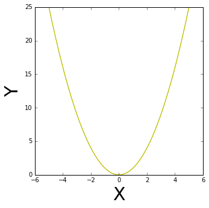

```python
#x = np.linspace(-100,100)
f = lambda x : x**2
#y = f(x)<
f_t = lambda x : 1 + 2*(x-1) +(x-1)**2
a = Dplot2D(fig_size=(5,5))
a.append_curve(f_t)
a.append_curve(f)
```

we can see that the taylor series of $f(x)=x^2$ entirely is the same as original one

Let's to investigate the function $f(x)=3x^3 + 2x^2 + x + 1$ The taylor expansion when $a=1$ is :
$\;\;\;\;\;\;\;\;\;\;\;\;\;\;\;\;\;$ $f(1)=7$ $\;\;\;\;\;\;\;\;\;\;\;\;\;\;\;\;\;$ $f^1(1)=14$ $\;\;\;\;\;\;\;\;\;\;\;\;\;\;\;\;\;$ $f(1)=22$ $\;\;\;\;\;\;\;\;\;\;\;\;\;\;\;\;\;$ $f(1)=18$ The function is :
$$f(x)= f^(1)+ \frac{f^1(x-1)}{1}.x+\frac{f^{2}(x-1)}{2.1}.x^2+ \frac{f^{3}(x-1)}{3.2.1}.x^3=7 + 14.(x-1) + 11.(x-1)^2 + 3.(x-1)^3 $$

Let's to investigate the graphs in case when n=2,then we have for : $$f(x)=7 + 14.(x-1) + 11.(x-1)^2$$

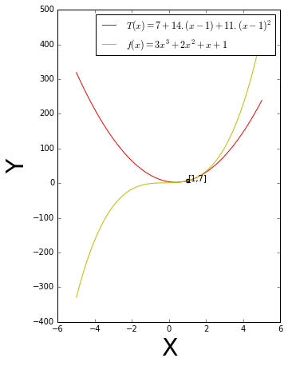

```python
#x = np.linspace(-100,100)
f = lambda x : 3*(x**3) + 2*(x**2) + x + 1
#y = f(x)<
f_t = lambda x : 7 + 14*(x-1) + 11*(x-1)**2
a = Dplot2D(fig_size=(5,7))
a.append_curve(f_t,label=r'$T(x)=7 + 14.(x-1) + 11.(x-1)^2$',color='r')
a.append_curve(f,label=r'$f(x)=3x^3 + 2x^2 + x + 1$')
a.append_point(1,7,text='[1,7]')
a.show()
```

!!! from above graphic

we can see the function $f(x)=3x^3 + 2x^2 + x + 1$ and Taylor series to 2 sedond derivite when a = 1 $T(x)=7 + 14.(x-1) + 11.(x-1)^2$ the two function is the same in interval near to x=1 but when x>2 and x<0 the function is entirly different that conslusion is importent because in small interval we can make

Taylor Appoximation :

$x=a+h$ the we have : $$T(a+h) \approx f(a) + \frac{f^{1}(a).h^1}{1}+\frac{f^{2}(a).h^2}{2.1}$$

$$f(a+h) - f(a) \approx \frac{f^{1}(a).h^1}{1}+\frac{f^{2}(a).h^2}{2.1}$$

lets to see what happen with our function $f(x)=3x^3 + 2x^2 + x + 1$ if we expand it to n=3 the we achiev that $$f(x)= f^(1)+ \frac{f^1(x-1)}{1}.x+\frac{f^{2}(x-1)}{2.1}.x^2+ \frac{f^{3}(x-1)}{3.2.1}.x^3=7 + 14.(x-1) + 11.(x-1)^2 + 3.(x-1)^3 $$

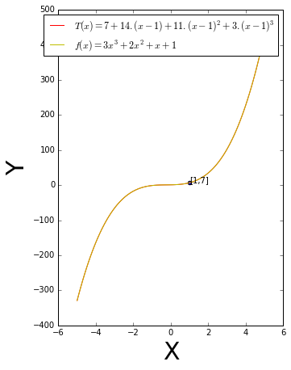

```python
#x = np.linspace(-100,100)
f = lambda x : 3*(x**3) + 2*(x**2) + x + 1
#y = f(x)<
f_t = lambda x : 7 + 14*(x-1) + 11*(x-1)**2 + 3*(x-1)**3
a = Dplot2D(fig_size=(5,7))
a.append_curve(f_t,label=r'$T(x)=7 + 14.(x-1) + 11.(x-1)^2 +3.(x-1)^3 $',color='r')
a.append_curve(f,label=r'$f(x)=3x^3 + 2x^2 + x + 1$')
a.append_point(1,7,text='[1,7]')
a.show()
```

!!! We can see when the function is expand to maximum poslible n the $T(x) = f(x)$

In addiotion let to proof most beautiful formula in matheics

### Taylor approximation of function with 2 variables

Let f be an infinitely differentiable function in some open neighborhood around (x, y) = (a, b)
$$f(x_1,x_2)\approx f(a,b)(x-a) + f_{x_1}(a,b)(x-a)+ f_{x_2}(a,b)(x-b) + \frac{1}{2!}[f_{x_1x_1}(a,b)(x-a)^2 +2f_{x_1x_2}(a,b)(x-a)(x-b)+f_{a,b}+f_{x_2x_2}(a,b)(x-b)^2]...$$ or in more compact form : $$ f(x) = f(a) + [(x-a)\nabla f(a)] +[(x-a)H(x)(x-a)]...$$ where $a = <a,b> $ $x=<x_1,x_2>$ and $$ Hesian \; H = \begin{bmatrix} f_{x_1x_1}&f_{x_1x_2} \\ f_{x_2x_2} & f_{x_2x_1} \end{bmatrix}=\begin{bmatrix} \frac{\partial^2{f}}{\partial{x_1}\partial{x_1}} & \frac{\partial^2{f}}{\partial{x_1}\partial{x_2}} \\ \frac{\partial^2{f}}{\partial{x_2}\partial{x_2}} & \frac{\partial^2{f}}{\partial{x_2}\partial{x_1}} \end{bmatrix}$$